# R Notebook

**Principles of Data Visualization and Introduction to ggplot2**

I have provided you with data about the 5,000 fastest growing companies in the US, as compiled by Inc. magazine. lets read this in:

```r
inc <- read.csv("https://raw.githubusercontent.com/charleyferrari/CUNY_DATA_608/master/module1/Data/inc5000_data.csv", header= TRUE)
```

And lets preview this data:

```r
head(inc)
```

```
##   Rank                         Name Growth_Rate   Revenue
## 1    1                         Fuhu      421.48 1.179e+08
## 2    2        FederalConference.com      248.31 4.960e+07
## 3    3                The HCI Group      245.45 2.550e+07
## 4    4                      Bridger      233.08 1.900e+09
## 5    5                       DataXu      213.37 8.700e+07
## 6    6 MileStone Community Builders      179.38 4.570e+07
##                       Industry Employees         City State
## 1 Consumer Products & Services       104   El Segundo    CA
## 2          Government Services        51     Dumfries    VA
## 3                       Health       132 Jacksonville    FL
## 4                       Energy        50      Addison    TX
## 5      Advertising & Marketing       220       Boston    MA
## 6                  Real Estate        63       Austin    TX
```

```r
summary(inc)
```

```
##       Rank          Name            Growth_Rate         Revenue
##  Min.   :   1   Length:5001        Min.   :  0.340   Min.   :2.000e+06
##  1st Qu.:1252   Class :character   1st Qu.:  0.770   1st Qu.:5.100e+06
##  Median :2502   Mode  :character   Median :  1.420   Median :1.090e+07
##  Mean   :2502                      Mean   :  4.612   Mean   :4.822e+07
##  3rd Qu.:3751                      3rd Qu.:  3.290   3rd Qu.:2.860e+07
##  Max.   :5000                      Max.   :421.480   Max.   :1.010e+10
##
##    Industry           Employees           City              State
##  Length:5001        Min.   :    1.0   Length:5001        Length:5001
##  Class :character   1st Qu.:   25.0   Class :character   Class :character
##  Mode  :character   Median :   53.0   Mode  :character   Mode  :character
##                     Mean   :  232.7
##                     3rd Qu.:  132.0
##                     Max.   :66803.0
##                     NA's   :12
```

Think a bit on what these summaries mean. Use the space below to add some more relevant non-visual exploratory information you think helps you understand this data:

```r
dim(inc)
```

```
## [1] 5001    8
```

```r
sapply(inc, class)
```

```
##        Rank        Name Growth_Rate     Revenue    Industry   Employees
##   "integer" "character"   "numeric"   "numeric" "character"   "integer"
##        City       State
## "character" "character"
```

```r
str(inc)
```

```
## 'data.frame':    5001 obs. of  8 variables:
##  $ Rank       : int  1 2 3 4 5 6 7 8 9 10 ...
##  $ Name       : chr  "Fuhu" "FederalConference.com" "The HCI Group" "Bridger" ...
##  $ Growth_Rate: num  421 248 245 233 213 ...
##  $ Revenue    : num  1.18e+08 4.96e+07 2.55e+07 1.90e+09 8.70e+07 ...
##  $ Industry   : chr  "Consumer Products & Services" "Government Services" "Health" "Energy" ...
##  $ Employees  : int  104 51 132 50 220 63 27 75 97 15 ...
##  $ City       : chr  "El Segundo" "Dumfries" "Jacksonville" "Addison" ...
##  $ State      : chr  "CA" "VA" "FL" "TX" ...
```

## Question 1

Create a graph that shows the distribution of companies in the dataset by State (ie how many are in each state). There are a lot of States, so consider which axis you should use. This visualization is ultimately going to be consumed on a ‘portrait’ oriented screen (ie taller than wide), which should further guide your layout choices.

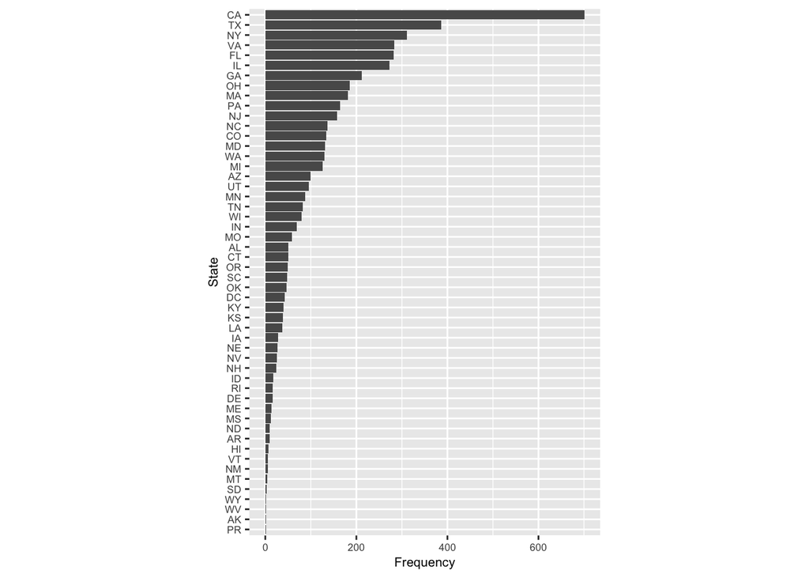

```r
# Answer Question 1 here
library(ggplot2)
q1.tbl <- data.frame(table(inc$State))

ggplot(data=q1.tbl, aes(x=Freq, y=reorder(Var1,Freq))) +
  geom_bar(stat="identity") +
  labs(x="Frequency", y="State") +
  theme(aspect.ratio=1.5,
        text=element_text(size=8))
```

## Quesiton 2

Lets dig in on the state with the 3rd most companies in the data set. Imagine you work for the state and are interested in how many people are employed by companies in different industries. Create a plot that shows the average and/or median employment by industry for companies in this state (only use cases with full data, use R’s `complete.cases()` function.) In addition to this, your graph should show how variable the ranges are, and you should deal with outliers.

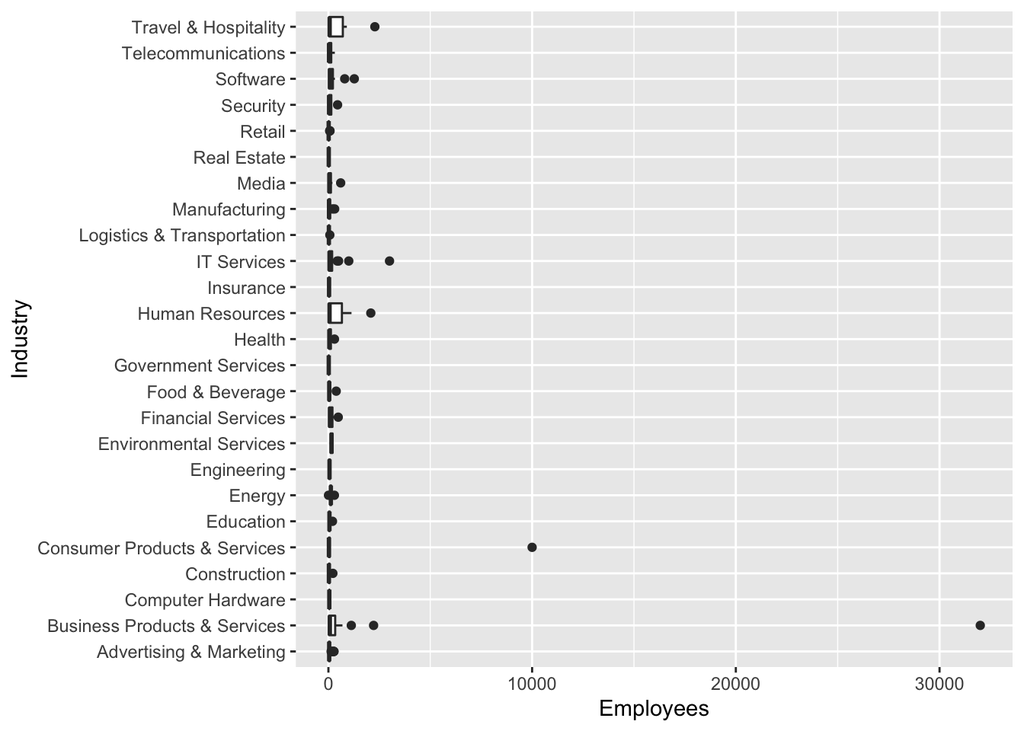

```r
# Answer Question 2 here
inc.complt <- inc[complete.cases(inc),]
inc.complt.ny <- inc.complt[inc.complt$State=="NY",]

# Detect outliers
ggplot(data=inc.complt.ny, aes(x=Employees, y=Industry, by=Industry)) +
  geom_boxplot()
```

```r
# list outlier companies to make note of them.
inc.complt.ny[inc.complt.ny$Employees > 1000,]
```

```
##      Rank                       Name Growth_Rate   Revenue
## 1498 1499       Sterling Infosystems        2.66 2.149e+08
## 2829 2830               ReSource Pro        1.22 2.430e+07
## 3135 3136     FSO Onsite Outsourcing        1.05 5.530e+07
## 3899 3899  Denihan Hospitality Group        0.71 2.808e+08
## 4363 4363               TransPerfect        0.55 3.413e+08
## 4465 4465                   OpenLink        0.52 3.043e+08
## 4577 4577 Sutherland Global Services        0.48 5.976e+08
## 4716 4716              Westcon Group        0.44 3.800e+09
## 4936 4936                       Coty        0.36 4.600e+09
##                          Industry Employees      City State
## 1498              Human Resources      2081  New York    NY
## 2829 Business Products & Services      1124  New York    NY
## 3135              Human Resources      1134  New York    NY
## 3899         Travel & Hospitality      2280  New York    NY
## 4363 Business Products & Services      2218  New York    NY
## 4465                     Software      1271 Uniondale    NY
## 4577 Business Products & Services     32000 Pittsford    NY
## 4716                  IT Services      3000 Tarrytown    NY
## 4936 Consumer Products & Services     10000  New York    NY
```

```r
# Get rid of 9 outliers with employees over 1000 to highlight the range
table(inc.complt.ny$Employees <= 1000)
```

```
##
## FALSE  TRUE
##     9   302
```

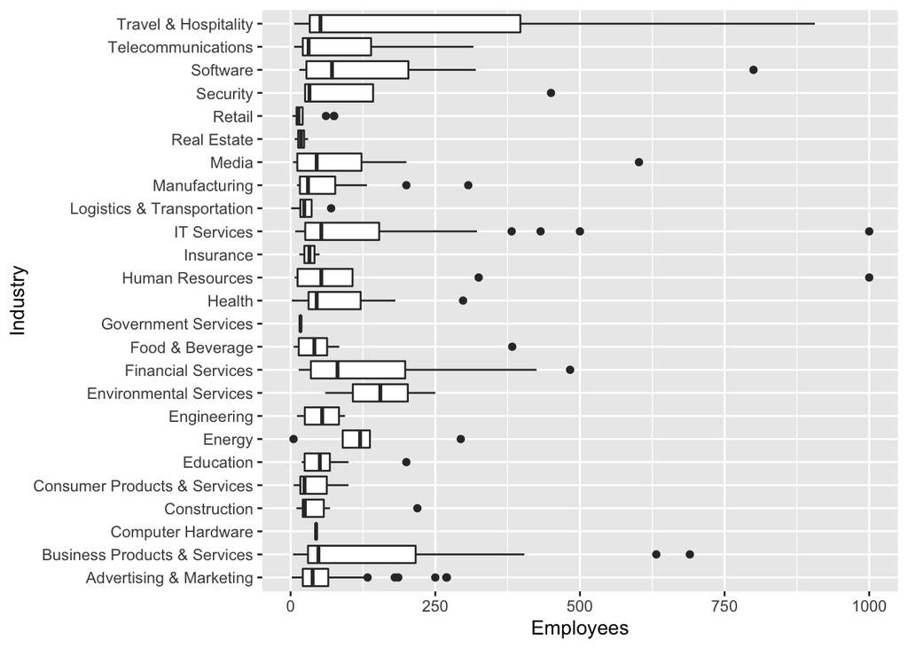

```r
inc.complt.ny.mod <- inc.complt.ny[inc.complt.ny$Employees <= 1000, ]

ggplot(data=inc.complt.ny.mod, aes(x=Employees, y=Industry, by=Industry)) +
  geom_boxplot()
```

## Question 3

Now imagine you work for an investor and want to see which industries generate the most revenue per employee. Create a chart that makes this information clear. Once again, the distribution per industry should be shown.

```r
# Answer Question 3 here

per.inds <- data.frame()
for (i in unique(inc.complt$Industry)) {
  per.inds <- rbind(per.inds,
                    colSums(inc.complt[inc.complt$Industry==i,c("Revenue","Employees")])
                    )

}
per.inds$"Industry" <- unique(inc.complt$Industry)
colnames(per.inds) <- c("Revenue","Employees","Industry")
per.inds$"rev.per.empl" <- per.inds$Revenue / per.inds$Employees

per.inds[order(-per.inds$rev.per.empl),]
```

```
##        Revenue Employees                     Industry rev.per.empl
## 10 11885700000      9714            Computer Hardware   1223563.93
## 4  13771600000     26437                       Energy    520921.44
## 16 13174300000     29099                 Construction    452740.64
## 11 14837800000     39994   Logistics & Transportation    371000.65
## 1  14956400000     45464 Consumer Products & Services    328972.37
## 25  2337900000      7339                    Insurance    318558.39
## 17 12603600000     43942                Manufacturing    286823.54
## 8  10257400000     37068                       Retail    276718.46
## 7  13150900000     47693           Financial Services    275740.67
## 23  2638800000     10155       Environmental Services    259852.29
## 18  7287900000     30842           Telecommunications    236297.91
## 2   6009100000     26185          Government Services    229486.35
## 14 26345900000    117357 Business Products & Services    224493.64
## 3  17860100000     82430                       Health    216669.90
## 13 20525000000    102788                  IT Services    199682.84
## 5   7785000000     39731      Advertising & Marketing    195942.71
## 12 12812500000     65911              Food & Beverage    194390.92
## 22  1742400000      9532                        Media    182794.80
## 9   8134600000     51262                     Software    158686.75
## 6   2956800000     18893                  Real Estate    156502.41
## 15  1139300000      7685                    Education    148249.84
## 21  2931600000     23035         Travel & Hospitality    127267.20
## 24  2532500000     20435                  Engineering    123929.53
## 19  3812800000     41059                     Security     92861.49
## 20  9246100000    226980              Human Resources     40735.31
```

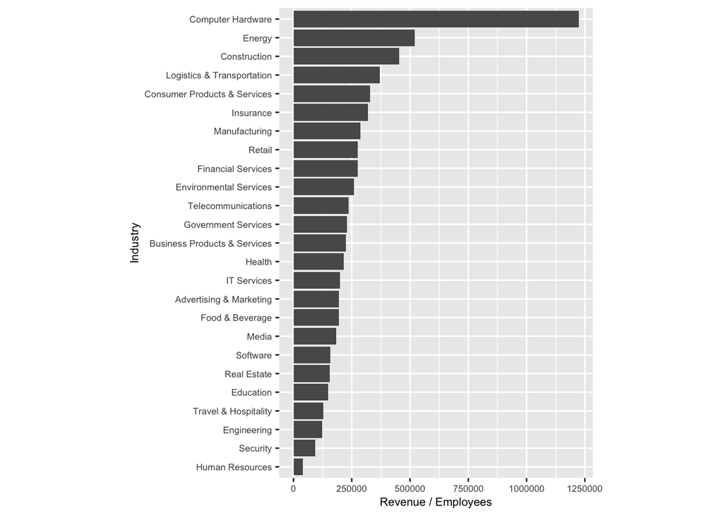

```r
ggplot(data=per.inds, aes(x=rev.per.empl, y=reorder(Industry,rev.per.empl))) +
  geom_bar(stat="identity") +
  #geom_text(aes(x=0, y=reorder(Industry,rev.per.empl),
  #              label=paste("$",Revenue," / ",Employees)), color='white', size=2, hjust=0.05) +
  labs(x="Revenue / Employees", y="Industry") +
  theme(aspect.ratio=1.5,
        text=element_text(size=8))
```